# homework_2_Lee_Jared

### 5) What happens if you make a scatterplot of class vs drv? Why is the plot not useful?

Answer: Both variables are descrete, so showing a table or raw numbers is a better visualization.

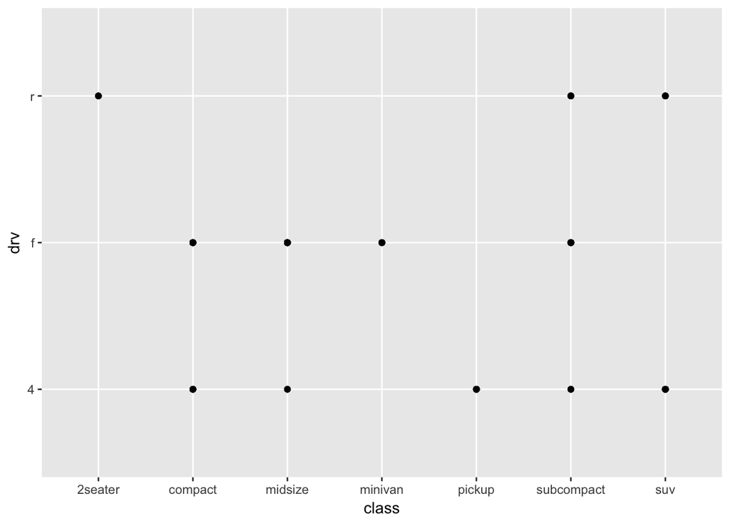

```r
ggplot(mpg) +
  geom_point(aes(class, drv))
```

## Section 3.3.1: all exercises

### 1) What’s gone wrong with this code? Why are the points not blue?

Since color = “blue” is inside the aesthetic function, R treats it like a dimension to be added as opposed to a color treatment. This should be outside of aes() instead.

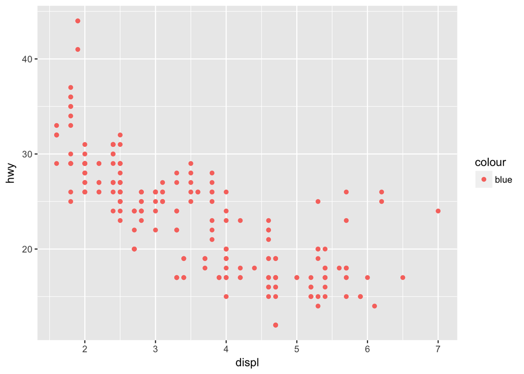

```r
ggplot(data = mpg) +
  geom_point(mapping = aes(x = displ, y = hwy, color = "blue"))
```

### 2) Which variables in mpg are categorical? Which variables are continuous? (Hint: type ?mpg to read the documentation for the dataset). How can you see this information when you run mpg?

manufacturer: categorical,

displ: continuous,

year: categorical,

cyl: categorical,

trans: categorical,

drv: categorical,

cty: continuous,

hwy: continuous,

fl: categorical,

class: categorical

```r
glimpse(mpg)
```

```
## Observations: 234
## Variables: 11
## $ manufacturer <chr> "audi", "audi", "audi", "audi", "audi", "audi", "...
## $ model        <chr> "a4", "a4", "a4", "a4", "a4", "a4", "a4", "a4 qua...
## $ displ        <dbl> 1.8, 1.8, 2.0, 2.0, 2.8, 2.8, 3.1, 1.8, 1.8, 2.0,...
## $ year         <int> 1999, 1999, 2008, 2008, 1999, 1999, 2008, 1999, 1...
## $ cyl          <int> 4, 4, 4, 4, 6, 6, 6, 4, 4, 4, 4, 6, 6, 6, 6, 6, 6...
## $ trans        <chr> "auto(l5)", "manual(m5)", "manual(m6)", "auto(av)...
## $ drv          <chr> "f", "f", "f", "f", "f", "f", "f", "4", "4", "4",...
## $ cty          <int> 18, 21, 20, 21, 16, 18, 18, 18, 16, 20, 19, 15, 1...
## $ hwy          <int> 29, 29, 31, 30, 26, 26, 27, 26, 25, 28, 27, 25, 2...
## $ fl           <chr> "p", "p", "p", "p", "p", "p", "p", "p", "p", "p",...
## $ class        <chr> "compact", "compact", "compact", "compact", "comp...
```

### 3) Map a continuous variable to color, size, and shape. How do these aesthetics behave differently for categorical vs. continuous variables? **

For color, continuous variables show a gradient. For categorical, each variable has their own unique color. Similarly with size, continuous variables are a scale of size from small to large. And categorical variables get their own unique size.

For Shape, continuous variables cannot be used as there is no scale for shapes.

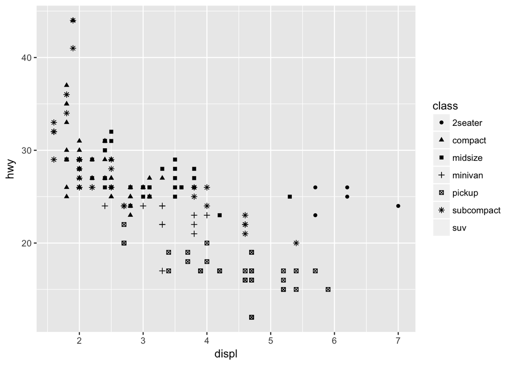

```r
ggplot(mpg) +
  geom_point(aes(x = displ, y = hwy, shape = class))
```

### 4) What happens if you map the same variable to multiple aesthetics?

It creates a linear line.

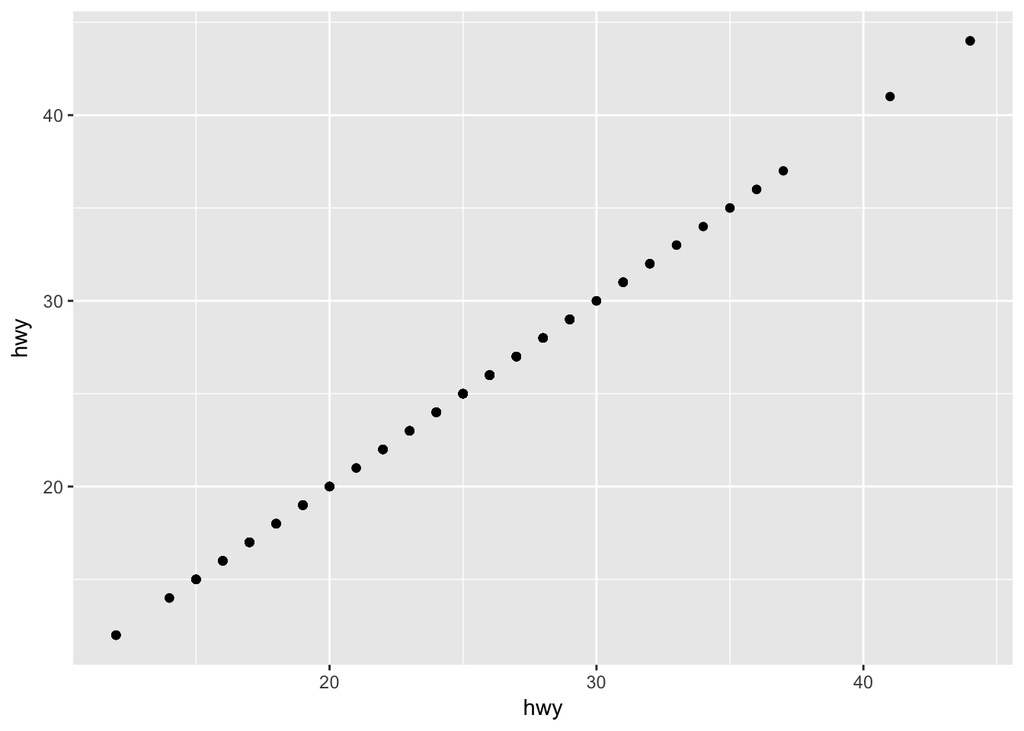

```r
ggplot(mpg) +
  geom_point(aes(x = hwy, y = hwy))
```

### 5) What does the stroke aesthetic do? What shapes does it work with? (Hint: use ?geom_point)

The stroke aesthetic defines the width or thickness of the border of the points.

```r
?geom_point
```

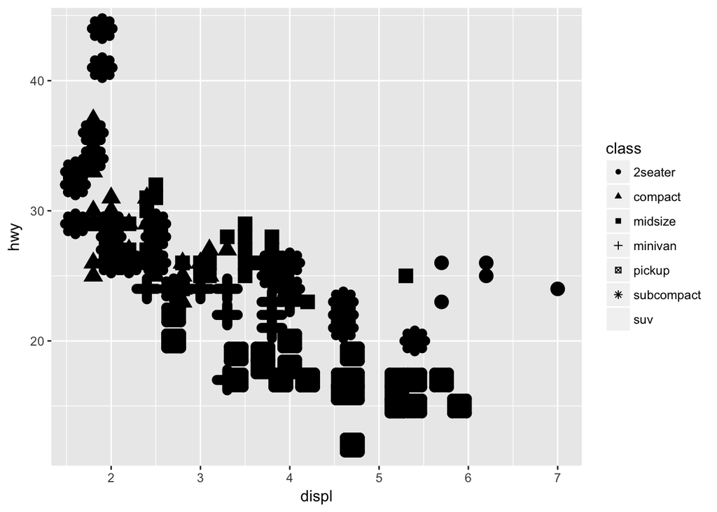

```r
ggplot(mpg) +
  geom_point(aes(x = displ, y = hwy, shape = class, stroke = 5))
```

### 6) What happens if you map an aesthetic to something other than a variable name, like aes(colour = displ < 5)?

A boolean is created.

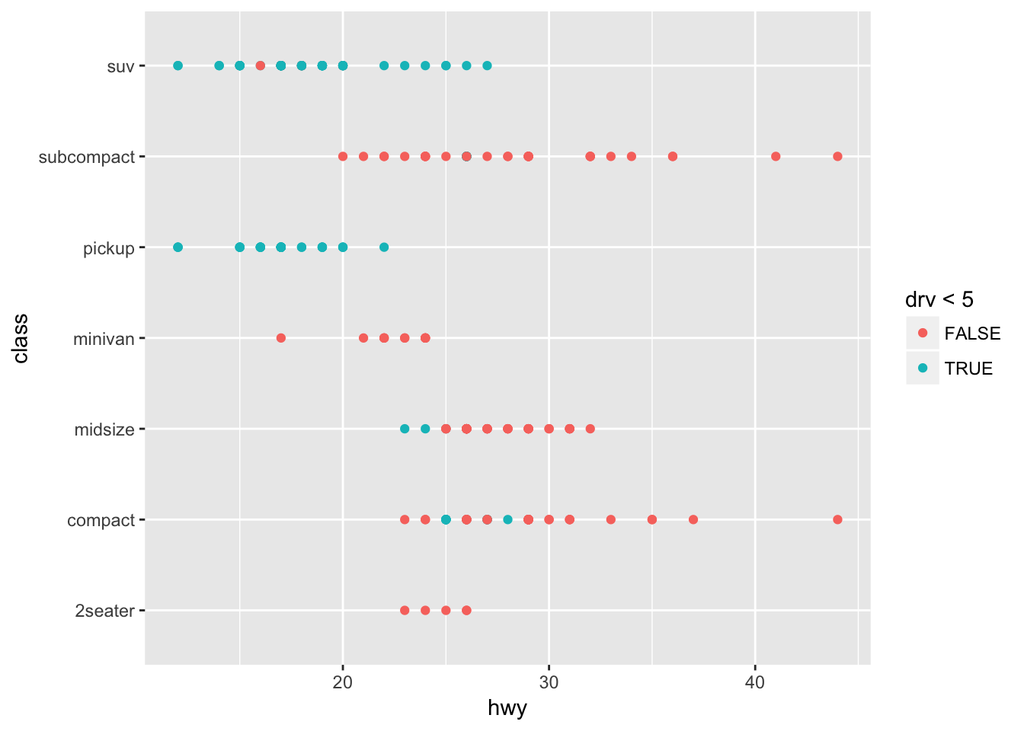

```r
ggplot(mpg) +
  geom_point(aes(x = hwy, y = class, colour = drv < 5))
```